# Project_EasyVisa_AML_AshishTR

## Problem Statement

### Context

Business communities in the United States are facing high demand for human resources, but one of the constant challenges is identifying and attracting the right talent, which is perhaps the most important element in remaining competitive. Companies in the United States look for hard-working, talented, and qualified individuals both locally as well as abroad.

The Immigration and Nationality Act (INA) of the US permits foreign workers to come to the United States to work on either a temporary or permanent basis. The act also protects US workers against adverse impacts on their wages or working conditions by ensuring US employers' compliance with statutory requirements when they hire foreign workers to fill workforce shortages. The immigration programs are administered by the Office of Foreign Labor Certification (OFLC).

OFLC processes job certification applications for employers seeking to bring foreign workers into the United States and grants certifications in those cases where employers can demonstrate that there are not sufficient US workers available to perform the work at wages that meet or exceed the wage paid for the occupation in the area of intended employment.

### Objective

In FY 2016, the OFLC processed 775,979 employer applications for 1,699,957 positions for temporary and permanent labor certifications. This was a nine percent increase in the overall number of processed applications from the previous year. The process of reviewing every case is becoming a tedious task as the number of applicants is increasing every year.

The increasing number of applicants every year calls for a Machine Learning based solution that can help in shortlisting the candidates having higher chances of VISA approval. OFLC has hired the firm EasyVisa for data-driven solutions. You as a data scientist at EasyVisa have to analyze the data provided and, with the help of a classification model:

1. Facilitate the process of visa approvals.
2. Recommend a suitable profile for the applicants for whom the visa should be certified or denied based on the drivers that significantly influence the case status.

### Data Description

The data contains the different attributes of the employee and the employer. The detailed data dictionary is given below.

- case_id: ID of each visa application
- continent: Information of continent the employee
- education_of_employee: Information of education of the employee
- has_job_experience: Does the employee has any job experience? Y= Yes; N = No
- requires_job_training: Does the employee require any job training? Y = Yes; N = No
- no_of_employees: Number of employees in the employer's company
- yr_of_estab: Year in which the employer's company was established
- region_of_employment: Information of foreign worker's intended region of employment in the US.
- prevailing_wage: Average wage paid to similarly employed workers in a specific occupation in the area of intended employment. The purpose of the prevailing wage is to ensure that the foreign worker is not underpaid compared to other workers offering the same or similar service in the same area of employment.
- unit_of_wage: Unit of prevailing wage. Values include Hourly, Weekly, Monthly, and Yearly.
- full_time_position: Is the position of work full-time? Y = Full-Time Position; N = Part-Time Position
- case_status: Flag indicating if the Visa was certified or denied

### Importing necessary libraries

```python
!pip install pandas==2.2.2 numpy==2.0.2 matplotlib==3.10.0 seaborn==0.13.2 scikit-learn==1.6.1 xgboost==2.1.4 -q
```

```python
!pip install imbalanced-learn
```

**Note:**

- On executing the above line of code, you might see a warning regarding package dependencies. This error message can be ignored as the above code ensures that all necessary libraries and their dependencies are maintained to successfully execute the code in this notebook.

```python
# Libraries to help with reading and manipulating data
import pandas as pd
import numpy as np

# Libaries to help with data visualization
import matplotlib.pyplot as plt
import seaborn as sns

# To tune model, get different metric scores, and split data
from sklearn.metrics import (
    f1_score,
    accuracy_score,
    recall_score,
    precision_score,
    confusion_matrix,
    roc_auc_score,
    ConfusionMatrixDisplay,
)
from sklearn.model_selection import train_test_split, StratifiedKFold, cross_val_score

# To be used for data scaling and one hot encoding
from sklearn.preprocessing import StandardScaler, MinMaxScaler, OneHotEncoder

# To impute missing values
from sklearn.impute import SimpleImputer
from sklearn import metrics

# To oversample and undersample data
from imblearn.over_sampling import SMOTE
from imblearn.under_sampling import RandomUnderSampler

# To do hyperparameter tuning
from sklearn.model_selection import RandomizedSearchCV

# To define maximum number of columns to be displayed in a dataframe
pd.set_option("display.max_columns", None)

# To supress scientific notations for a dataframe
pd.set_option("display.float_format", lambda x: "%.3f" % x)

# To help with model building
from sklearn.tree import DecisionTreeClassifier
from sklearn.ensemble import (
    AdaBoostClassifier,
    GradientBoostingClassifier,
    RandomForestClassifier,
    BaggingClassifier,
)
from xgboost import XGBClassifier
from sklearn.linear_model import LogisticRegression

# To suppress scientific notations
pd.set_option("display.float_format", lambda x: "%.3f" % x)

# To help with outlier detection
from scipy.stats.mstats import winsorize

# To supress warnings
import warnings

warnings.filterwarnings("ignore")
```

### Loading the dataset

```python
data = pd.read_csv("/Users/ashiravi/Cisco_Lenovo_bkup_26022018/D/Training_docs/GreatLearning_UTexas_AI_ML/Advanced_machine_learning/EasyVisa.csv")
```

```python
# Create a copy of the data
df = data.copy()
```

## Data Overview

```python
# Checking the number of rows and columns in the data
df.shape
```

```
(25480, 12)
```

#### Observations:

There are 25480 rows and 12 columns in the dataset.

### Displaying the first few and last rows of the dataset

```python
# Viewing first 5 rows of the data
df.head()
```

|  | case_id | continent | education_of_employee | has_job_experience | requires_job_training | no_of_employees | yr_of_estab | region_of_employment | prevailing_wage | unit_of_wage | full_time_position | case_status |
| --- | --- | --- | --- | --- | --- | --- | --- | --- | --- | --- | --- | --- |
| 0 | EZYV01 | Asia | High School | N | N | 14513 | 2007 | West | 592.203 | Hour | Y | Denied |
| 1 | EZYV02 | Asia | Master's | Y | N | 2412 | 2002 | Northeast | 83425.650 | Year | Y | Certified |
| 2 | EZYV03 | Asia | Bachelor's | N | Y | 44444 | 2008 | West | 122996.860 | Year | Y | Denied |
| 3 | EZYV04 | Asia | Bachelor's | N | N | 98 | 1897 | West | 83434.030 | Year | Y | Denied |
| 4 | EZYV05 | Africa | Master's | Y | N | 1082 | 2005 | South | 149907.390 | Year | Y | Certified |

```python
# Viewing the last 5 rows of the data
df.tail()
```

|  | case_id | continent | education_of_employee | has_job_experience | requires_job_training | no_of_employees | yr_of_estab | region_of_employment | prevailing_wage | unit_of_wage | full_time_position | case_status |
| --- | --- | --- | --- | --- | --- | --- | --- | --- | --- | --- | --- | --- |
| 25475 | EZYV25476 | Asia | Bachelor's | Y | Y | 2601 | 2008 | South | 77092.570 | Year | Y | Certified |
| 25476 | EZYV25477 | Asia | High School | Y | N | 3274 | 2006 | Northeast | 279174.790 | Year | Y | Certified |
| 25477 | EZYV25478 | Asia | Master's | Y | N | 1121 | 1910 | South | 146298.850 | Year | N | Certified |
| 25478 | EZYV25479 | Asia | Master's | Y | Y | 1918 | 1887 | West | 86154.770 | Year | Y | Certified |
| 25479 | EZYV25480 | Asia | Bachelor's | Y | N | 3195 | 1960 | Midwest | 70876.910 | Year | Y | Certified |

### Check the data types of the columns in the dataset

```python
# Check the data types of the columns in the dataset
df.info()
```

```
<class 'pandas.core.frame.DataFrame'>
RangeIndex: 25480 entries, 0 to 25479
Data columns (total 12 columns):
 #   Column                 Non-Null Count  Dtype
---  ------                 --------------  -----
 0   case_id                25480 non-null  object
 1   continent              25480 non-null  object
 2   education_of_employee  25480 non-null  object
 3   has_job_experience     25480 non-null  object
 4   requires_job_training  25480 non-null  object
 5   no_of_employees        25480 non-null  int64
 6   yr_of_estab            25480 non-null  int64
 7   region_of_employment   25480 non-null  object
 8   prevailing_wage        25480 non-null  float64
 9   unit_of_wage           25480 non-null  object
 10  full_time_position     25480 non-null  object
 11  case_status            25480 non-null  object
dtypes: float64(1), int64(2), object(9)
memory usage: 2.3+ MB
```

#### Observations:

- There are no missing values in all 12 columns.
- There are 3 numerical variables and others are categorical variables in the dataset.

```python
# Check for duplicate values in the data
df.duplicated().sum()
```

```
np.int64(0)
```

#### Observations:

There are no duplicate values in dataset.

```python
# Check for summary of the dataset
df.describe()
```

|  | no_of_employees | yr_of_estab | prevailing_wage |
| --- | --- | --- | --- |
| count | 25480.000 | 25480.000 | 25480.000 |
| mean | 5667.043 | 1979.410 | 74455.815 |
| std | 22877.929 | 42.367 | 52815.942 |
| min | -26.000 | 1800.000 | 2.137 |
| 25% | 1022.000 | 1976.000 | 34015.480 |
| 50% | 2109.000 | 1997.000 | 70308.210 |
| 75% | 3504.000 | 2005.000 | 107735.513 |
| max | 602069.000 | 2016.000 | 319210.270 |

#### Observations:

- There are some wrong entries like negative value of number of employees
- There are big difference between min and max for number of employees and wages which will be cause of outliers.

```python
# Checking and removing negative values in 'no_of_employees' column
df.loc[df['no_of_employees']< 0]
```

|  | case_id | continent | education_of_employee | has_job_experience | requires_job_training | no_of_employees | yr_of_estab | region_of_employment | prevailing_wage | unit_of_wage | full_time_position | case_status |
| --- | --- | --- | --- | --- | --- | --- | --- | --- | --- | --- | --- | --- |
| 245 | EZYV246 | Europe | Master's | N | N | -25 | 1980 | Northeast | 39452.990 | Year | Y | Certified |
| 378 | EZYV379 | Asia | Bachelor's | N | Y | -11 | 2011 | Northeast | 32506.140 | Year | Y | Denied |
| 832 | EZYV833 | South America | Master's | Y | N | -17 | 2002 | South | 129701.940 | Year | Y | Certified |
| 2918 | EZYV2919 | Asia | Master's | Y | N | -26 | 2005 | Midwest | 112799.460 | Year | Y | Certified |
| 6439 | EZYV6440 | Asia | Bachelor's | N | N | -14 | 2013 | South | 103.970 | Hour | Y | Denied |
| 6634 | EZYV6635 | Asia | Bachelor's | Y | N | -26 | 1923 | West | 5247.320 | Year | Y | Denied |
| 7224 | EZYV7225 | Europe | Doctorate | N | N | -25 | 1998 | Midwest | 141435.950 | Year | Y | Certified |
| 7281 | EZYV7282 | Asia | High School | N | N | -14 | 2000 | Midwest | 58488.500 | Year | Y | Denied |
| 7318 | EZYV7319 | Asia | Bachelor's | Y | Y | -26 | 2006 | South | 115005.610 | Year | Y | Certified |
| 7761 | EZYV7762 | Asia | Master's | N | N | -11 | 2009 | Midwest | 38457.510 | Year | Y | Certified |
| 9872 | EZYV9873 | Europe | Master's | Y | N | -26 | 1996 | South | 37397.050 | Year | Y | Certified |
| 11493 | EZYV11494 | Asia | High School | Y | N | -14 | 1999 | South | 27599.350 | Year | Y | Denied |
| 13471 | EZYV13472 | North America | Master's | N | N | -17 | 2003 | Northeast | 257.241 | Hour | Y | Denied |
| 14022 | EZYV14023 | Asia | Bachelor's | N | Y | -11 | 1946 | Northeast | 108403.560 | Year | Y | Certified |
| 14146 | EZYV14147 | Asia | Bachelor's | N | Y | -26 | 1954 | West | 81982.270 | Year | Y | Certified |
| 14726 | EZYV14727 | Asia | Master's | N | N | -11 | 2000 | Midwest | 167851.800 | Year | Y | Certified |
| 15600 | EZYV15601 | Asia | Bachelor's | N | N | -14 | 2014 | South | 24641.610 | Year | Y | Denied |
| 15859 | EZYV15860 | Asia | High School | N | N | -11 | 1969 | South | 44640.600 | Year | Y | Denied |
| 16157 | EZYV16158 | Asia | Master's | Y | N | -11 | 1994 | South | 62681.250 | Year | Y | Certified |
| 16883 | EZYV16884 | North America | Bachelor's | Y | N | -26 | 1968 | Northeast | 168.156 | Hour | Y | Denied |
| 17006 | EZYV17007 | Asia | Doctorate | Y | N | -11 | 1984 | West | 25753.510 | Year | Y | Denied |
| 17655 | EZYV17656 | North America | Bachelor's | Y | N | -17 | 2007 | Northeast | 129753.180 | Year | Y | Denied |
| 17844 | EZYV17845 | Asia | Bachelor's | N | N | -14 | 2012 | West | 29325.850 | Year | Y | Denied |
| 17983 | EZYV17984 | Asia | Bachelor's | N | N | -26 | 2004 | South | 84359.980 | Year | Y | Denied |
| 20815 | EZYV20816 | Asia | Bachelor's | N | Y | -17 | 1990 | West | 91897.570 | Year | Y | Certified |
| 20984 | EZYV20985 | Europe | Doctorate | Y | N | -14 | 1989 | Midwest | 37012.800 | Year | Y | Certified |
| 21255 | EZYV21256 | North America | High School | N | N | -25 | 1987 | South | 99405.470 | Year | N | Denied |
| 21760 | EZYV21761 | Asia | Bachelor's | Y | N | -25 | 2000 | West | 100463.580 | Year | Y | Certified |
| 21944 | EZYV21945 | Africa | Master's | Y | N | -25 | 1977 | Midwest | 79150.510 | Year | Y | Certified |
| 22084 | EZYV22085 | North America | Bachelor's | Y | N | -14 | 1980 | West | 691.061 | Hour | Y | Denied |
| 22388 | EZYV22389 | Asia | Master's | Y | N | -14 | 1986 | South | 17893.110 | Year | Y | Certified |
| 23186 | EZYV23187 | Asia | Master's | N | Y | -11 | 2007 | Midwest | 120195.350 | Year | Y | Certified |
| 23476 | EZYV23477 | Europe | Master's | Y | N | -11 | 2000 | West | 95072.750 | Year | Y | Denied |

```python
# Replacing negative values in 'no_of_employees' with their absolute values
df["no_of_employees"] = abs(df["no_of_employees"])
#df.loc[df['no_of_employees']< 0]
```

## Exploratory Data Analysis

```python
# Remove the 'case_id' column as it is not needed for analysis
df.drop(["case_id"], axis=1, inplace=True)
```

## Univariate Analysis

```python
# Function to create labeled barplot
def labeled_barplot(data, feature, perc=False, n=None):
    """
    Barplot with percentage at the top

    data: dataframe
    feature: dataframe column
    perc: whether to display percentages instead of count (default is False)
    n: displays the top n category levels (default is None, i.e., display all levels)
    """

    total = len(data[feature])  # length of the column
    count = data[feature].nunique()
    if n is None:
        plt.figure(figsize=(count + 1, 5))
    else:
        plt.figure(figsize=(n + 1, 5))

    plt.xticks(rotation=90, fontsize=15)
    ax = sns.countplot(
        data=data,
        x=feature,
        palette="Paired",
        order=data[feature].value_counts().index[:n].sort_values(),
    )

    for p in ax.patches:
        if perc == True:
            label = "{:.1f}%".format(
                100 * p.get_height() / total
            )  # percentage of each class of the category
        else:
            label = p.get_height()  # count of each level of the category

        x = p.get_x() + p.get_width() / 2  # width of the plot
        y = p.get_height()  # height of the plot

        ax.annotate(
            label,
            (x, y),
            ha="center",
            va="center",
            size=12,
            xytext=(0, 5),
            textcoords="offset points",
        )  # annotate the percentage

    plt.show()  # show the plot
```

```
Categorical Feature: continent
```

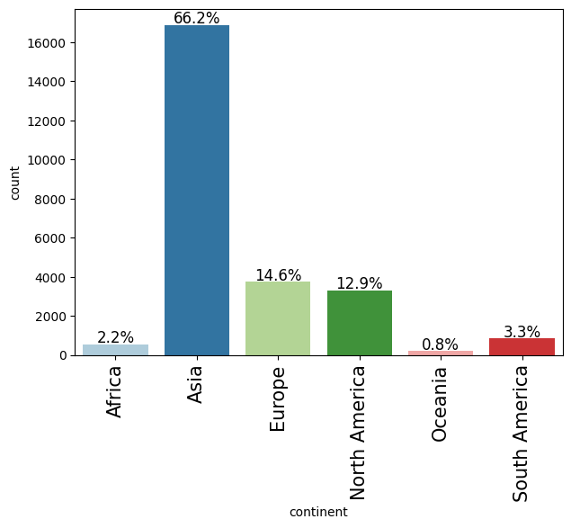

```
Categorical Feature: education_of_employee
```

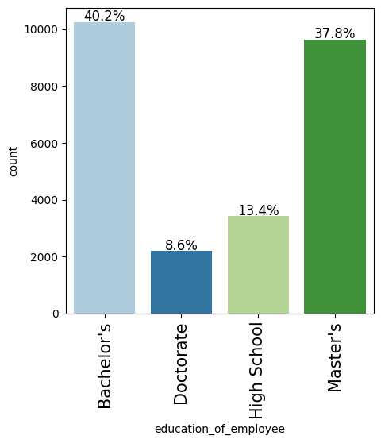

```
Categorical Feature: has_job_experience
```

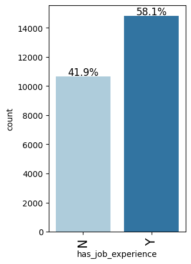

```
Categorical Feature: requires_job_training
```

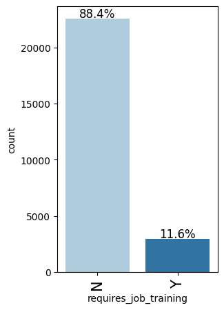

```
Categorical Feature: region_of_employment
```

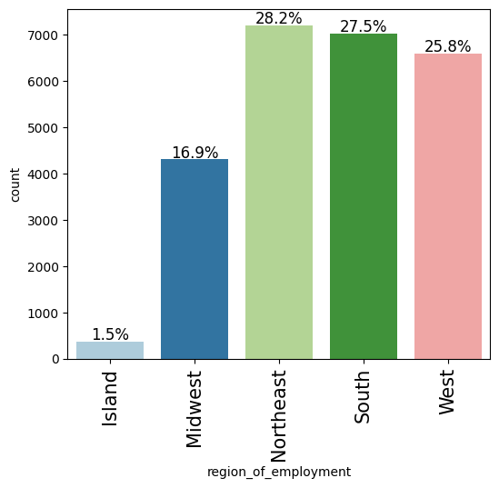

```
Categorical Feature: unit_of_wage
```

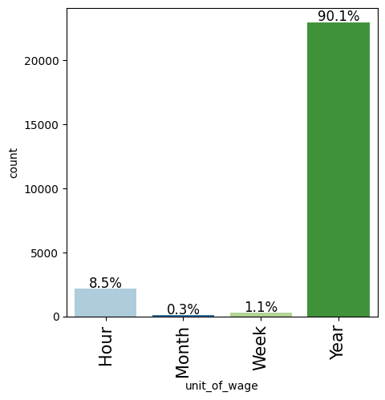

```
Categorical Feature: full_time_position
```

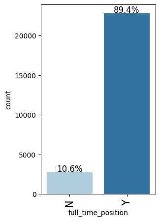

```
Categorical Feature: case_status
```

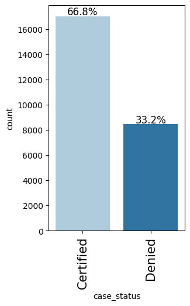

```
Numerical Feature: no_of_employees
```

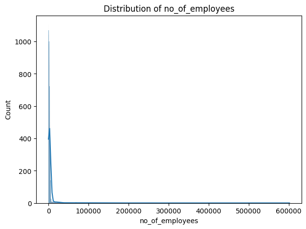

```
Numerical Feature: yr_of_estab
```

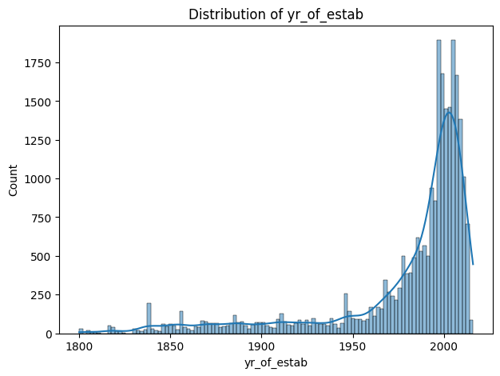

```
Numerical Feature: prevailing_wage
```

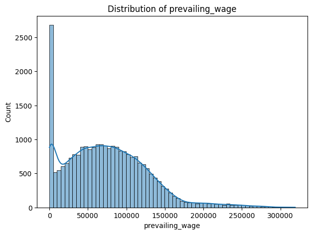

```python
# Univariate analysis for all columns using labeled_barplot for categorical and hist for numerical
categorical_cols = [
    'continent', 'education_of_employee', 'has_job_experience', 'requires_job_training',
    'region_of_employment', 'unit_of_wage', 'full_time_position', 'case_status'
]
numerical_cols = ['no_of_employees', 'yr_of_estab', 'prevailing_wage']

for col in categorical_cols:
    print(f"Categorical Feature: {col}")
    labeled_barplot(df, col, perc=True)

for col in numerical_cols:
    print(f"Numerical Feature: {col}")
    plt.figure(figsize=(7,5))
    sns.histplot(df[col], kde=True)
    plt.title(f"Distribution of {col}")
    plt.show()
```

### Bivariate analysis

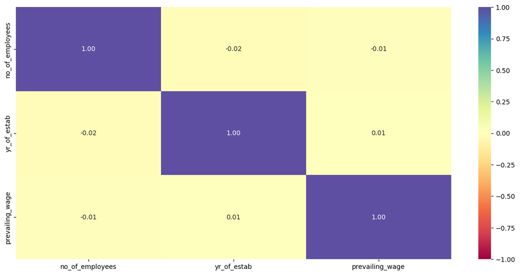

```python
plt.figure(figsize=(15, 7))
sns.heatmap(data.corr(numeric_only = True), annot=True, vmin=-1, vmax=1, fmt=".2f", cmap="Spectral")
plt.show()
```

#### Observations of Heatmap

Most correlations are weak, indicating that these variables are largely independent of each other.

```python
# function to plot stacked barchart
def stacked_barplot(data, predictor, target):
    """
    Print the category counts and plot a stacked bar chart

    data: dataframe
    predictor: independent variable
    target: target variable
    """
    count = data[predictor].nunique()
    sorter = data[target].value_counts().index[-1]
    tab1 = pd.crosstab(data[predictor], data[target], margins=True).sort_values(
        by=sorter, ascending=False
    )
    print(tab1)
    print("-" * 120)
    tab = pd.crosstab(data[predictor], data[target], normalize="index").sort_values(
        by=sorter, ascending=False
    )
    tab.plot(kind="bar", stacked=True, figsize=(count + 1, 5))
    plt.legend(
        loc="lower left", frameon=False,
    )
    plt.legend(loc="upper left", bbox_to_anchor=(1, 1))
    plt.show()
```

```python
# Function to plot distributions
def distribution_plot_wrt_target(data, predictor, target):

    fig, axs = plt.subplots(2, 2, figsize=(12, 10))

    target_uniq = data[target].unique()

    axs[0, 0].set_title("Distribution of target for target=" + str(target_uniq[0]))
    sns.histplot(
        data=data[data[target] == target_uniq[0]],
        x=predictor,
        kde=True,
        ax=axs[0, 0],
        color="teal",
    )

    axs[0, 1].set_title("Distribution of target for target=" + str(target_uniq[1]))
    sns.histplot(
        data=data[data[target] == target_uniq[1]],
        x=predictor,
        kde=True,
        ax=axs[0, 1],
        color="orange",
    )

    axs[1, 0].set_title("Boxplot w.r.t target")
    sns.boxplot(data=data, x=target, y=predictor, ax=axs[1, 0], palette="gist_rainbow")

    axs[1, 1].set_title("Boxplot (without outliers) w.r.t target")
    sns.boxplot(
        data=data,
        x=target,
        y=predictor,
        ax=axs[1, 1],
        showfliers=False,
        palette="gist_rainbow",
    )

    plt.tight_layout()
    plt.show()
```

```
case_status    Certified  Denied    All
continent
All                17018    8462  25480
Asia               11012    5849  16861
North America       2037    1255   3292
Europe              2957     775   3732
South America        493     359    852
Africa               397     154    551
Oceania              122      70    192
------------------------------------------------------------------------------------------------------------------------
```

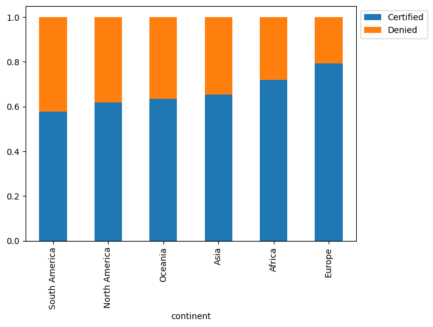

```python
stacked_barplot(df, "continent", "case_status")
```

##### Observation

Europe has highest approved candidates followed by Africa and Asia. South American continent candidates seems to have least approvals

```
case_status            Certified  Denied    All
education_of_employee
All                        17018    8462  25480
Bachelor's                  6367    3867  10234
High School                 1164    2256   3420
Master's                    7575    2059   9634
Doctorate                   1912     280   2192
------------------------------------------------------------------------------------------------------------------------
```

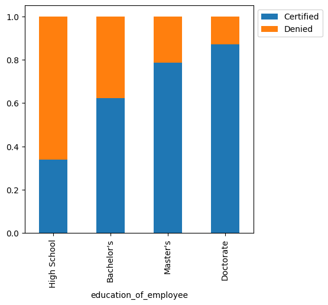

```python
stacked_barplot(df, "education_of_employee", "case_status")
```

##### Observation

From this plot it seems higher the education higher the chances of visa approval

```
case_status         Certified  Denied    All
has_job_experience
All                     17018    8462  25480
N                        5994    4684  10678
Y                       11024    3778  14802
------------------------------------------------------------------------------------------------------------------------
```

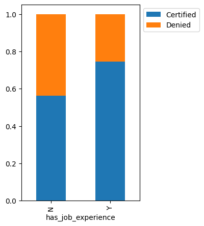

```python
stacked_barplot(df, "has_job_experience", "case_status")
```

##### Observation

People with job experience have higher visa approval rate

```
case_status            Certified  Denied    All
requires_job_training
All                        17018    8462  25480
N                          15012    7513  22525
Y                           2006     949   2955
------------------------------------------------------------------------------------------------------------------------
```

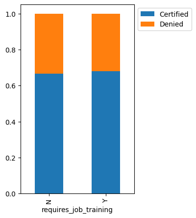

```python
stacked_barplot(df, "requires_job_training", "case_status")
```

```
case_status           Certified  Denied    All
region_of_employment
All                       17018    8462  25480
Northeast                  4526    2669   7195
West                       4100    2486   6586
South                      4913    2104   7017
Midwest                    3253    1054   4307
Island                      226     149    375
------------------------------------------------------------------------------------------------------------------------
```

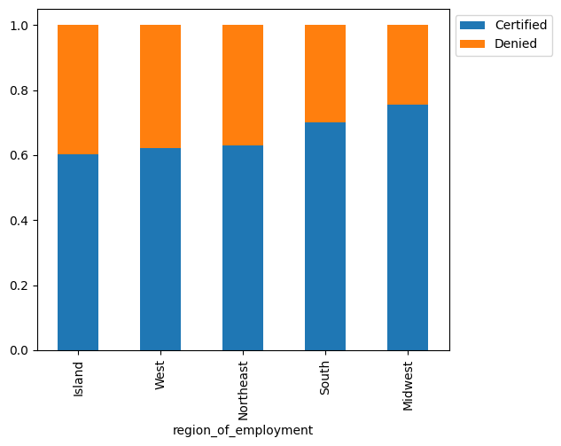

```python
stacked_barplot(df, "region_of_employment", "case_status")
```

```
case_status   Certified  Denied    All
unit_of_wage
All               17018    8462  25480
Year              16047    6915  22962
Hour                747    1410   2157
Week                169     103    272
Month                55      34     89
------------------------------------------------------------------------------------------------------------------------
```

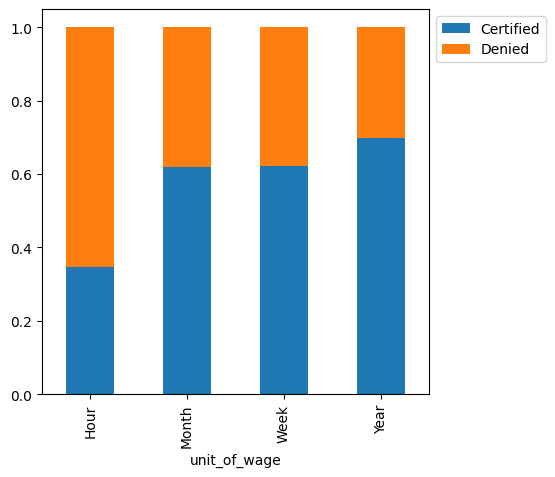

```python
stacked_barplot(df, "unit_of_wage", "case_status")
```

##### Observation

Applications with yearly wages have higher visa approval rate as compared to hourly wages.

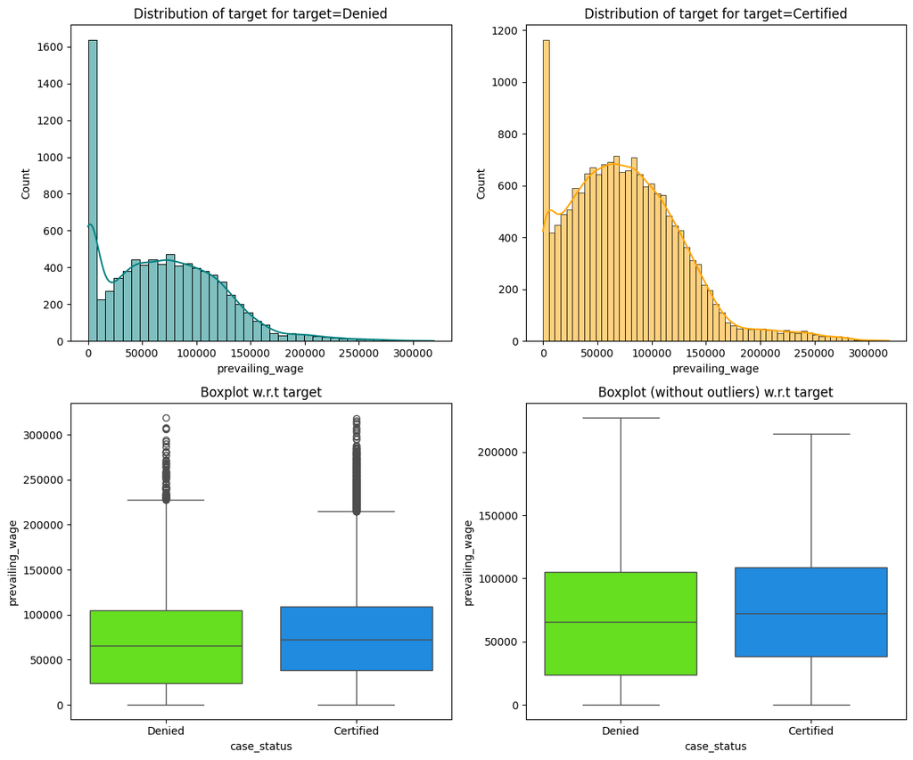

```python
distribution_plot_wrt_target(df, "prevailing_wage", "case_status")
```

##### Observation

Prevaliing wages could be feature used for prediction. It seems like mid to higher wage have higher likelihood of certification

## Data pre-processing

### Missing Value Detection and Treatment

```python
# Check for missing values
df.isnull().sum()
```

```
continent                0
education_of_employee    0
has_job_experience       0
requires_job_training    0
no_of_employees          0
yr_of_estab              0
region_of_employment     0
prevailing_wage          0
unit_of_wage             0
full_time_position       0
case_status              0
dtype: int64
```

#### Observation

No missing values hence no treatment being done.

### Outlier Detection and Treatment

Detecting outliers in numerical features.

```python
# Outlier detection using IQR
for col in ['no_of_employees', 'yr_of_estab', 'prevailing_wage']:
    Q1 = df[col].quantile(0.25)
    Q3 = df[col].quantile(0.75)
    IQR = Q3 - Q1
    outliers = df[(df[col] < Q1 - 1.5 * IQR) | (df[col] > Q3 + 1.5 * IQR)]
    print(f'{col}: {len(outliers)} outliers')
```

```
no_of_employees: 1556 outliers
yr_of_estab: 3260 outliers
prevailing_wage: 427 outliers
```

#### Observation

Outliers is present in all three numerical features. For preparing data for modeling let us remove the extreme outliers of prevailing_wage.

```python
# The lowest 1% and highest 1% of values will be replaced with the 1st and 99th percentile value respectively.
df['prevailing_wage'] = winsorize(df['prevailing_wage'], limits=[0.01, 0.01])
```

### Feature Engineering

- Encode categorical variables.
- Scale numerical features.
- Prepare target variable.

```python
# Encode target
df['case_status'] = df['case_status'].map({'Certified': 1, 'Denied': 0})


# One-hot encode categorical features
cat_cols = ['continent', 'education_of_employee', 'has_job_experience', 'requires_job_training', 'region_of_employment', 'unit_of_wage', 'full_time_position']
df_encoded = pd.get_dummies(df, columns=cat_cols, drop_first=True)
print("Shape after encoding categorical features:", df_encoded.shape)

# Scale numerical features
scaler = StandardScaler()
num_cols = ['no_of_employees', 'yr_of_estab', 'prevailing_wage']
df_encoded[num_cols] = scaler.fit_transform(df_encoded[num_cols])

# Prepare X and y
X = df_encoded.drop(['case_status'], axis=1)
y = df_encoded['case_status']

print("Shape of X:", X.shape)
print("Class balance:\n", y.value_counts(normalize=True))

# Check for missing values
print("Missing values in X:\n", X.isnull().sum().sum())
```

```
Shape after encoding categorical features: (25480, 22)
Shape of X: (25480, 21)
Class balance:
 case_status
1   0.668
0   0.332
Name: proportion, dtype: float64
Missing values in X:
 0
```

#### Observations

Data set is now properly encoded, scaled, cleaned and preparation of data for modelling has been done.

## Model Building - Original Data

Build and evaluate 6 classification models i.e. DecisionTree, RandomForest, Bagging, AdaBoost, GradientBoosting and XGBoost.

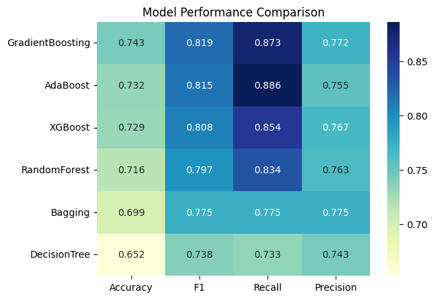

```python
# Train-test split
X_train, X_test, y_train, y_test = train_test_split(X, y, test_size=0.2, stratify=y, random_state=42)

# Define models
models = {
    'DecisionTree': DecisionTreeClassifier(random_state=42),
    'RandomForest': RandomForestClassifier(random_state=42),
    'Bagging': BaggingClassifier(random_state=42),
    'AdaBoost': AdaBoostClassifier(random_state=42),
    'GradientBoosting': GradientBoostingClassifier(random_state=42),
    'XGBoost': XGBClassifier(use_label_encoder=False, eval_metric='logloss', random_state=42),
}

# Train and evaluate
results = {}
for name, model in models.items():
    model.fit(X_train, y_train)
    y_pred = model.predict(X_test)
    results[name] = {
        'Accuracy': accuracy_score(y_test, y_pred),
        'F1': f1_score(y_test, y_pred),
        'Recall': recall_score(y_test, y_pred),
        'Precision': precision_score(y_test, y_pred)
    }
pd.DataFrame(results).T

# import seaborn as sns
# import matplotlib.pyplot as plt

results_df = pd.DataFrame(results).T.sort_values(by='F1', ascending=False)
sns.heatmap(results_df, annot=True, fmt=".3f", cmap="YlGnBu")
plt.title("Model Performance Comparison")
plt.show()
```

#### Observation

Overall, GradientBoosting and AdaBoost appear to be strong performers across multiple metrics. XGBoost and RandomForest also show good results.

## Model Building - Oversampled Data

Apply SMOTE to balance classes and rebuild models.

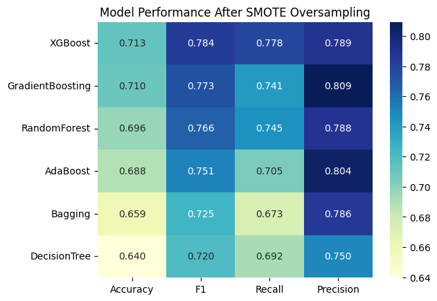

```python
# Oversample training data
smote = SMOTE(random_state=42)
X_train_over, y_train_over = smote.fit_resample(X_train, y_train)

results_over = {}
for name, model in models.items():
    model.fit(X_train_over, y_train_over)
    y_pred = model.predict(X_test)
    results_over[name] = {
        'Accuracy': accuracy_score(y_test, y_pred),
        'F1': f1_score(y_test, y_pred),
        'Recall': recall_score(y_test, y_pred),
        'Precision': precision_score(y_test, y_pred)
    }
pd.DataFrame(results_over).T

results_df_over = pd.DataFrame(results_over).T.sort_values(by='F1', ascending=False)
sns.heatmap(results_df_over, annot=True, fmt=".3f", cmap="YlGnBu")
plt.title("Model Performance After SMOTE Oversampling")
plt.show()
```

#### Observation

XGBoost and GradientBoosting are the Top Performers;

- XGBoost has the highest F1 score (0.784) and Recall (0.778).
- GradientBoosting achieves the highest Precision (0.809).

## Model Building - Undersampled Data

Applying random undersampling and rebuild models.

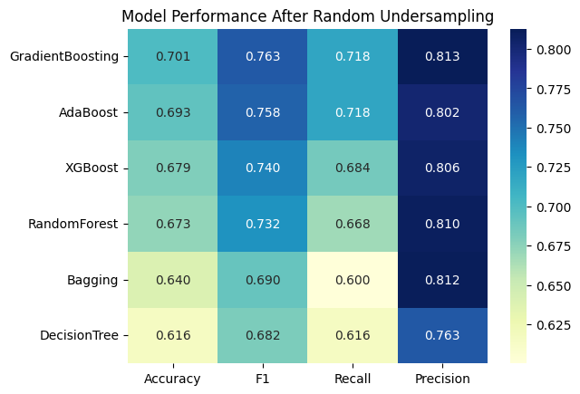

```python
# Undersample training data
rus = RandomUnderSampler(random_state=42)
X_train_under, y_train_under = rus.fit_resample(X_train, y_train)

results_under = {}
for name, model in models.items():
    model.fit(X_train_under, y_train_under)
    y_pred = model.predict(X_test)
    results_under[name] = {
        'Accuracy': accuracy_score(y_test, y_pred),
        'F1': f1_score(y_test, y_pred),
        'Recall': recall_score(y_test, y_pred),
        'Precision': precision_score(y_test, y_pred)
    }
pd.DataFrame(results_under).T

results_df_under = pd.DataFrame(results_under).T.sort_values(by='F1', ascending=False)
sns.heatmap(results_df_under, annot=True, fmt=".3f", cmap="YlGnBu")
plt.title("Model Performance After Random Undersampling")
plt.show()
```

#### Observation

GradientBoosting generally exhibits the best performance across most metrics. It achieves the highest Accuracy (0.701), F1 score (0.763), and Precision (0.813). It also ties with AdaBoost for the highest Recall (0.718).

## Model Comparison: Original, Oversampled, and Undersampled data

Compare the F1 scores of all models across the three approaches and select the top models overall.

|  | Original | Oversampled | Undersampled |
| --- | --- | --- | --- |
| GradientBoosting | 0.819 | 0.773 | 0.763 |
| AdaBoost | 0.815 | 0.751 | 0.758 |
| XGBoost | 0.808 | 0.784 | 0.740 |
| RandomForest | 0.797 | 0.766 | 0.732 |
| Bagging | 0.775 | 0.725 | 0.690 |
| DecisionTree | 0.738 | 0.720 | 0.682 |

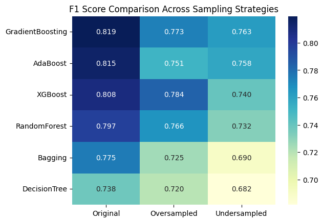

```
Top 3 models based on F1 score:
GradientBoosting   0.819
AdaBoost           0.815
XGBoost            0.808
Name: Best_F1, dtype: float64

Top 3 Models - Original Data
GradientBoosting   0.819
AdaBoost           0.815
XGBoost            0.808
Name: Original, dtype: float64

Top 3 Models - Oversampled Data
XGBoost            0.784
GradientBoosting   0.773
RandomForest       0.766
Name: Oversampled, dtype: float64

Top 3 Models - Undersampled Data
GradientBoosting   0.763
AdaBoost           0.758
XGBoost            0.740
Name: Undersampled, dtype: float64
```

```python
# Combine results from all three approaches
comparison_df = pd.DataFrame({
    'Original': pd.DataFrame(results).T['F1'],
    'Oversampled': pd.DataFrame(results_over).T['F1'],
    'Undersampled': pd.DataFrame(results_under).T['F1']
})

comparison_df = comparison_df.sort_values(by=['Original', 'Oversampled', 'Undersampled'], ascending=False)
display(comparison_df)

# Visual comparison
sns.heatmap(comparison_df, annot=True, fmt='.3f', cmap='YlGnBu')
plt.title('F1 Score Comparison Across Sampling Strategies')
plt.show()

# Find top 3 models by max F1 score across all strategies
comparison_df['Best_F1'] = comparison_df.max(axis=1)
top3_models = comparison_df['Best_F1'].sort_values(ascending=False).head(3)
print('Top 3 models based on F1 score:')
print(top3_models)

# Top 3 models for each sampling strategy
top3_original = comparison_df['Original'].sort_values(ascending=False).head(3)
top3_oversampled = comparison_df['Oversampled'].sort_values(ascending=False).head(3)
top3_undersampled = comparison_df['Undersampled'].sort_values(ascending=False).head(3)

print("\nTop 3 Models - Original Data")
print(top3_original)

print("\nTop 3 Models - Oversampled Data")
print(top3_oversampled)

print("\nTop 3 Models - Undersampled Data")
print(top3_undersampled)
```

#### Observation

Overall tree consistent models that show high and consistent F1 performance across all sampling strategies are GradientBoosting, AdaBoost and XGBoost.

However RandomForest also showed up in top three of oversampled data hence will choose following 4 models for hyperparameter tuning -

- GradientBoosting
- AdaBoost
- XGBoost
- RandomForest

## Hyperparameter Tuning

Above selected 4 models will be tuned

```python
# RandomForest tuning
rf = RandomForestClassifier(random_state=42)
rf_params = {'n_estimators': [50, 100, 200], 'max_depth': [5, 10, None]}
rf_search = RandomizedSearchCV(rf, rf_params, scoring='f1', cv=3, n_iter=5, random_state=42)
rf_search.fit(X_train, y_train)

# GradientBoosting tuning
gb = GradientBoostingClassifier(random_state=42)
gb_params = {
    'n_estimators': [50, 100, 200],
    'learning_rate': [0.01, 0.05, 0.1, 0.2],
    'max_depth': [3, 5, 7, None]
}
gb_search = RandomizedSearchCV(gb, gb_params, scoring='f1', cv=3, n_iter=8, random_state=42)
gb_search.fit(X_train, y_train)

# AdaBoost tuning
ab = AdaBoostClassifier(random_state=42)
ab_params = {
    'n_estimators': [50, 100, 200],
    'learning_rate': [0.01, 0.05, 0.1, 0.5, 1.0]
}
ab_search = RandomizedSearchCV(ab, ab_params, scoring='f1', cv=3, n_iter=8, random_state=42)
ab_search.fit(X_train, y_train)

# XGBoost tuning
xgb = XGBClassifier(use_label_encoder=False, eval_metric='logloss', random_state=42)
xgb_params = {
    'n_estimators': [50, 100, 200],
    'learning_rate': [0.01, 0.05, 0.1, 0.2],
    'max_depth': [3, 5, 7],
    'subsample': [0.7, 0.8, 1.0]
}
xgb_search = RandomizedSearchCV(xgb, xgb_params, scoring='f1', cv=3, n_iter=8, random_state=42)
xgb_search.fit(X_train, y_train)

# Evaluate tuned models
tuned_results = {}
for name, search in zip(['RandomForest', 'GradientBoosting', 'AdaBoost', 'XGBoost'], [rf_search, gb_search, ab_search, xgb_search]):
    y_pred = search.predict(X_test)
    tuned_results[name] = {
        'Best Params': search.best_params_,
        'Accuracy': accuracy_score(y_test, y_pred),
        'F1': f1_score(y_test, y_pred),
        'Recall': recall_score(y_test, y_pred),
        'Precision': precision_score(y_test, y_pred)
    }
pd.DataFrame(tuned_results).T
```

|  | Best Params | Accuracy | F1 | Recall | Precision |
| --- | --- | --- | --- | --- | --- |
| RandomForest | {'n_estimators': 200, 'max_depth': 10} | 0.743 | 0.821 | 0.882 | 0.767 |
| GradientBoosting | {'n_estimators': 50, 'max_depth': 3, 'learning... | 0.744 | 0.820 | 0.875 | 0.772 |
| AdaBoost | {'n_estimators': 200, 'learning_rate': 0.5} | 0.728 | 0.811 | 0.877 | 0.755 |
| XGBoost | {'subsample': 0.7, 'n_estimators': 50, 'max_de... | 0.740 | 0.818 | 0.875 | 0.768 |

## Final Model Selection and Evaluation

Compare the tuned models and select the best performing model based on F1 score and other metrics.

|  | Accuracy | F1 | Recall | Precision |
| --- | --- | --- | --- | --- |
| RandomForest | 0.743 | 0.821 | 0.882 | 0.767 |
| GradientBoosting | 0.744 | 0.820 | 0.875 | 0.772 |
| XGBoost | 0.740 | 0.818 | 0.875 | 0.768 |
| AdaBoost | 0.728 | 0.811 | 0.877 | 0.755 |

```
Final selected model: RandomForest
Test Accuracy: 0.7425431711145997
Test F1: 0.8207650273224044
Test Recall: 0.882491186839013
Test Precision: 0.7671092951991828
```

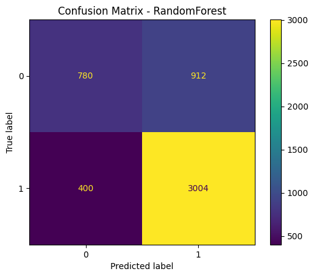

```python
# Compare tuned models
tuned_df = pd.DataFrame(tuned_results).T[['Accuracy', 'F1', 'Recall', 'Precision']]
tuned_df = tuned_df.sort_values(by='F1', ascending=False)
display(tuned_df)

# Select final model (highest F1 score)
final_model_name = tuned_df.index[0]
print(f'Final selected model: {final_model_name}')

# Get the corresponding search object
final_search = {'RandomForest': rf_search, 'GradientBoosting': gb_search, 'AdaBoost': ab_search, 'XGBoost': xgb_search}[final_model_name]

# Evaluate on test data
y_pred_final = final_search.predict(X_test)
print('Test Accuracy:', accuracy_score(y_test, y_pred_final))
print('Test F1:', f1_score(y_test, y_pred_final))
print('Test Recall:', recall_score(y_test, y_pred_final))
print('Test Precision:', precision_score(y_test, y_pred_final))

# Confusion matrix
ConfusionMatrixDisplay.from_estimator(final_search, X_test, y_test)
plt.title(f'Confusion Matrix - {final_model_name}')
plt.show()
```

#### Observation

Final model chosen is RandomForest because of following reasons -

- Highest F1 Score (0.821): Best balance of precision and recall.
- Highest Recall (0.882): Captures more true positives.
- Competitive Accuracy (0.743): Only 0.001 less than GradientBoosting (0.744).
- Decent Precision (0.767): Slightly lower than GradientBoosting, but still strong.

```
Top 10 Important Features:
```

|  | Feature | Importance |
| --- | --- | --- |
| 9 | education_of_employee_High School | 0.208 |
| 2 | prevailing_wage | 0.153 |
| 11 | has_job_experience_Y | 0.125 |
| 10 | education_of_employee_Master's | 0.098 |
| 0 | no_of_employees | 0.070 |
| 1 | yr_of_estab | 0.062 |
| 19 | unit_of_wage_Year | 0.062 |
| 8 | education_of_employee_Doctorate | 0.045 |
| 4 | continent_Europe | 0.038 |
| 13 | region_of_employment_Midwest | 0.023 |

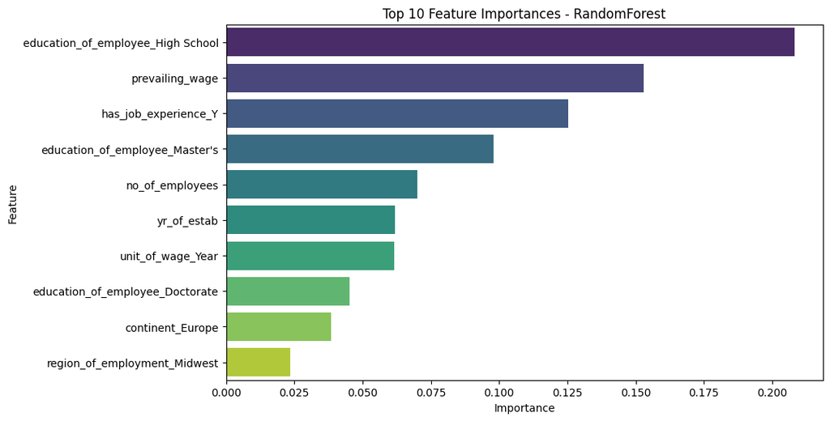

```python
# Feature importance extraction and visualization
if hasattr(final_search.best_estimator_, 'feature_importances_'):
    importances = final_search.best_estimator_.feature_importances_
    feature_names = X.columns
    feat_imp_df = pd.DataFrame({'Feature': feature_names, 'Importance': importances})
    feat_imp_df = feat_imp_df.sort_values(by='Importance', ascending=False)
    print('Top 10 Important Features:')
    display(feat_imp_df.head(10))
    plt.figure(figsize=(10,6))
    sns.barplot(x='Importance', y='Feature', data=feat_imp_df.head(10), palette='viridis')
    plt.title(f'Top 10 Feature Importances - {final_model_name}')
    plt.show()
elif hasattr(final_search.best_estimator_, 'coef_'):
    importances = final_search.best_estimator_.coef_[0]
    feature_names = X.columns
    feat_imp_df = pd.DataFrame({'Feature': feature_names, 'Importance': np.abs(importances)})
    feat_imp_df = feat_imp_df.sort_values(by='Importance', ascending=False)
    print('Top 10 Important Features:')
    display(feat_imp_df.head(10))
    plt.figure(figsize=(10,6))
    sns.barplot(x='Importance', y='Feature', data=feat_imp_df.head(10), palette='viridis')
    plt.title(f'Top 10 Feature Importances - {final_model_name}')
    plt.show()
else:
    print('Feature importances not available for this model.')
```

#### Observation

Employee profile features — especially education, experience, and offered wage — are the strongest predictors of case approval. Employer- and location-related factors play a secondary role.

## Actionable Insights & Recommendations

### Key Feature Drivers

- **Prevailing wage, education level, job experience, and continent** are among the top features influencing visa approval.
- Applicants with higher education, prior job experience applying for higher prevailing wages category have a greater likelihood of certification.
- Certain regions and wage units (yearly) are associated with higher approval rates.

### Business Takeaways

- Machine learning models can significantly streamline the visa approval process, reducing manual workload and improving decision consistency.
- Data-driven insights help identify the most promising candidates, enabling more efficient resource allocation and better compliance with regulatory requirements.
- By focusing on the most influential features, EasyVisa can provide targeted guidance to applicants and employers, increasing overall approval rates and satisfaction.